# Model Vignette

Brian Yandell

8/10/2022

```r
library(ewing)
```

## Modular approach

This was developed 18 Nov 2002 and updated 10 Aug 2022.

A big change is that I have modularized things. The default species are now “host” and “parasite”. There is a second library called “redscale” that has redscale and aphytis and comperiella and encarsia. (Actually, host is just redscale, and parasite is just aphytis). Now you can set up a new system by just creating a new library package.

The second big change is that I use R conventions of passing arguments, rather than hiding things as I have done inthe past. Now you do

```r
mysim <- init.simulation(interact = FALSE)
```

```
## Data organism.features loaded
## Initializing Temperature Profile ...
## Base daily temperature fluctuation:
## Temperature set for days 0 to 202
## Daily low temperature range: 68 to 77
## Daily high temperature range: 83 to 92
## Run temp.design() to adjust temperature range
## Initial active temperature:
## lo.hour hi.hour
##       0      24
## Creating simulation organism set using species:
##  host, parasite
##
## Data future.host loaded
## Data substrate.host loaded
## Data future.parasite loaded
## Data host.parasite loaded
## Data substrate.parasite loaded
## Data substrate.substrate loaded
##
## Initialize host at size 200 :...
## Initializing events for host with 200 individuals
## Initialize parasite at size 200 :...
## Initializing events for parasite with 200 individuals
```

```r
simres <- future.events(mysim, "mysim.out", plotit = FALSE)
```

```
## initial: host 200: parasite 200
## lo.hour hi.hour
##       0      48
## lo.hour hi.hour
##       0     120
## lo.hour hi.hour
##       0     240
## refresh 200: host 234: parasite 200
## refresh 400: host 255: parasite 200
## lo.hour hi.hour
##      24     336
## refresh 600: host 278: parasite 200
## refresh 800: host 294: parasite 200
## lo.hour hi.hour
##      48     576
## refresh 1000: host 352: parasite 200
## refresh 1200: host 403: parasite 200
## refresh 1400: host 442: parasite 200
## refresh 1600: host 483: parasite 200
## refresh 1800: host 538: parasite 200
## refresh 2000: host 578: parasite 200
## refresh 2200: host 585: parasite 200
## refresh 2400: host 585: parasite 200
## refresh 2600: host 585: parasite 200
## refresh 2800: host 585: parasite 200
## refresh 3000: host 585: parasite 200
## refresh 3200: host 585: parasite 200
## refresh 3400: host 585: parasite 200
## refresh 3600: host 585: parasite 200
## refresh 3800: host 585: parasite 200
## refresh 4000: host 585: parasite 200
```

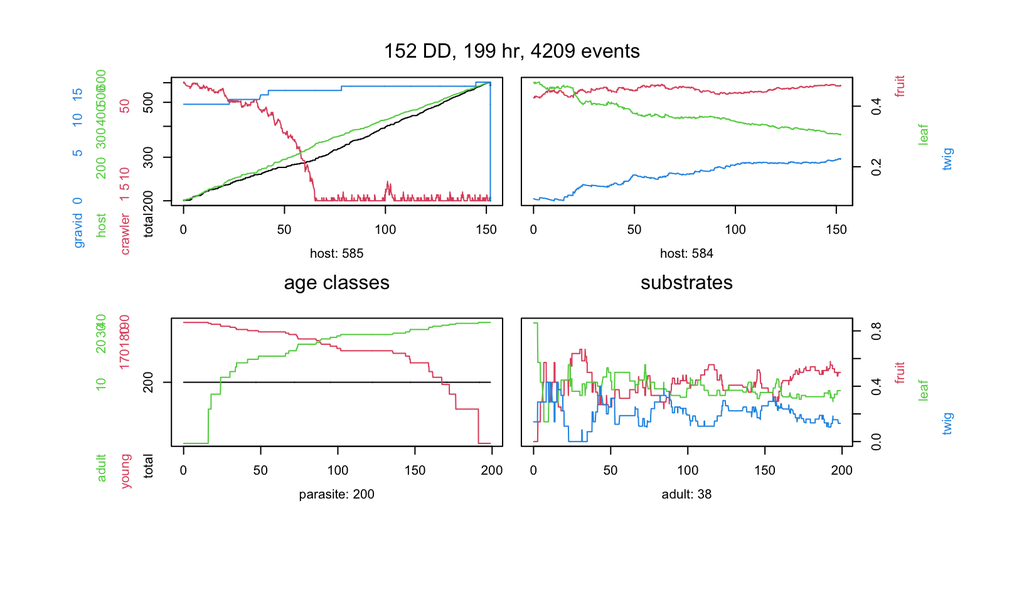

```r
plot(simres)
```

The object “mysim” has the initial populations and the organism and temperature structures. The object “simres” has the populations after running future.events (used to be step.future), along with summary information from the run.

I have also modularized the immediate, pending and future events. The functions

```
event.birth birth immediate event
event.attack    attack immediate event
event.death death pending event
event.future    generic future event
```

You can supply your own version of these if you don’t like mine. And you can add new ones by making appropriate changes in the “event” column of the future.host and future.parasite column. Adding a new kind of event, such as migrate means the routine now looks for a routine called “event.migrate”. Also, event.attack uses the type of parasite (endo,ecto) and the actual event (feed,ovip) to look for routines like event.ecto.feed to process attack details.

## Another attempt

Some of the data are stored in different ways, and it will take me awhile to sort out what is going on. For now stick to the above script.

```
data(redscale)
```

```
redscale.run <- init.population(redscale, 200)
```